# Aplicaciones del modelo de regresión lineal: relacción entre la variable respuesta y los regresores

10 octubre 2019

# 1 Datos

```r
d = read.csv("datos/kidiq.csv")
str(d)
```

```
## 'data.frame':    434 obs. of  5 variables:
##  $ kid_score: int  65 98 85 83 115 98 69 106 102 95 ...
##  $ mom_hs   : int  1 1 1 1 1 0 1 1 1 1 ...
##  $ mom_iq   : num  121.1 89.4 115.4 99.4 92.7 ...
##  $ mom_work : int  4 4 4 3 4 1 4 3 1 1 ...
##  $ mom_age  : int  27 25 27 25 27 18 20 23 24 19 ...
```

Las variables son las siguientes:

- **kid_score**: puntuacion de un test cognitivo en niños de 3-4 años
- **mom_hs**:
  - mom_hs = 1: las madres han terminado high school
  - mom_hs = 0: las madres no terminaron high school
- **mom_iq**: puntuación de la madre en un test IQ
- **mom_work**:
  - mom_work = 1: la madre no trabajó en los primeros tres años del niño
  - mom_work = 2: la madre trabajó en el 2do o tercer año
  - mom_work = 3: la madre trabajó a tiempo parcial el primer año
  - mom_work = 4: la madre trabajó a tiempo completo el primer año
- **mom_age**: edad de la madre

Convertimos a factor las variables cualitativas:

```r
d$mom_hs = factor(d$mom_hs, labels = c("no","yes"))
d$mom_work = factor(d$mom_work)
```

# 2 Un regresor cualitativo

Estimamos el modelo

$$kid\_score_i = \beta_0 + \beta_1 mom\_hsyes_i + u_i$$

donde *mom_hsyes* es una variable auxiliar con valores 0,1:

- mom_hs = yes => mom_hsyes = 1
- mom_hs = no => mom_hsyes = 0

```r
m1 = lm(kid_score ~ mom_hs, data = d)
summary(m1)
```

```
##
## Call:
## lm(formula = kid_score ~ mom_hs, data = d)
##
## Residuals:
##    Min     1Q Median     3Q    Max
## -57.55 -13.32   2.68  14.68  58.45
##
## Coefficients:
##             Estimate Std. Error t value Pr(>|t|)
## (Intercept)   77.548      2.059  37.670  < 2e-16 ***
## mom_hsyes     11.771      2.322   5.069 5.96e-07 ***
## ---
## Signif. codes:  0 '***' 0.001 '**' 0.01 '*' 0.05 '.' 0.1 ' ' 1
##
## Residual standard error: 19.85 on 432 degrees of freedom
## Multiple R-squared:  0.05613,    Adjusted R-squared:  0.05394
## F-statistic: 25.69 on 1 and 432 DF,  p-value: 5.957e-07
```

Tenemos dos modelos

- mom_hsyes = 0:

$$kid\_score_i = \hat \beta_0 + e_i$$

Como los residuos siempre suman cero:

$$\sum kid\_score_i = \sum \hat \beta_0 + \sum e_i \Rightarrow \frac{1}{n_1}\sum kid\_score_i = \hat \beta_0$$

Es decir, $\hat \beta_0$ es la media de las puntuaciones de los chicos cuyas madres no han terminado el bachillerato.

```r
# lo comprobamos en R
mean(d$kid_score[d$mom_hs=="no"])
```

```
## [1] 77.54839
```

- mom_hsyes = 1:

$$kid\_score_i = \hat \beta_0 + \hat \beta_1 mom\_hsyes_i + e_i$$

Como los residuos suman cero:

$$\sum kid\_score_i = \sum \hat \beta_0 + \sum \hat \beta_1 mom\_hsyes_i + \sum e_i \Rightarrow \frac{1}{n_2}\sum kid\_score_i = \hat \beta_0 + \hat \beta_1$$

```r
# en R
mean(d$kid_score[d$mom_hs=="yes"]) - mean(d$kid_score[d$mom_hs=="no"])
```

```
## [1] 11.77126
```

Por tanto, el contraste:

$$H_0: \beta_1 = 0 \\
H_1: \beta_1 \neq 0$$

nos indica si dicha diferencia es estadísticamente significativa o no. Mirando el pvalor correspondiente, se rechaza H0, luego los hijos de madres con bachillerato tienen una puntuación mayor que los hijos de madres sin bachillerato (una puntuación 11.77 puntos superior en promedio).

Gráficamente:

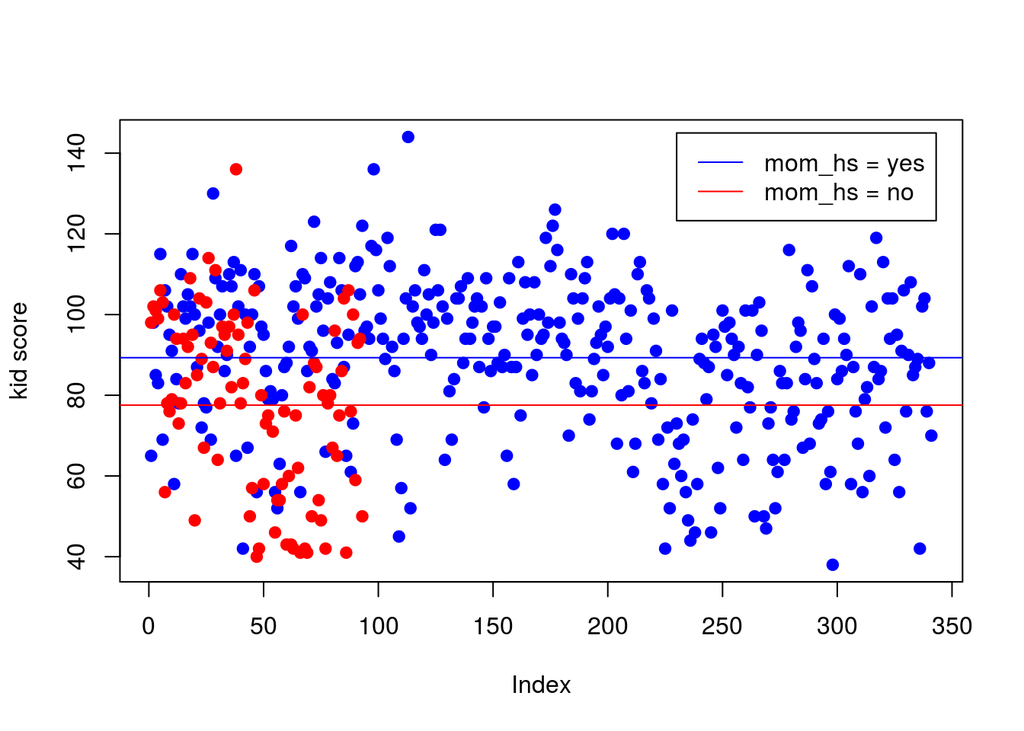

```r
plot(d$kid_score[d$mom_hs=="yes"], col = "blue", pch = 19, ylab = "kid score")
points(d$kid_score[d$mom_hs=="no"], col = "red", pch = 19)
abline(h=m1$coeff[1], col = "red")
abline(h=m1$coeff[1]+m1$coef[2], col = "blue")
legend(230,145, legend = c("mom_hs = yes","mom_hs = no"), col = c("blue","red"), lty = c(1,1))
```

# 3 Un regresor cuantitativo

```r
m2 = lm(kid_score ~ mom_iq, data = d)
summary(m2)
```

```
##
## Call:
## lm(formula = kid_score ~ mom_iq, data = d)
##
## Residuals:
##     Min      1Q  Median      3Q     Max
## -56.753 -12.074   2.217  11.710  47.691
##
## Coefficients:
##             Estimate Std. Error t value Pr(>|t|)
## (Intercept) 25.79978    5.91741    4.36 1.63e-05 ***
## mom_iq       0.60997    0.05852   10.42  < 2e-16 ***
## ---
## Signif. codes:  0 '***' 0.001 '**' 0.01 '*' 0.05 '.' 0.1 ' ' 1
##
## Residual standard error: 18.27 on 432 degrees of freedom
## Multiple R-squared:  0.201,  Adjusted R-squared:  0.1991
## F-statistic: 108.6 on 1 and 432 DF,  p-value: < 2.2e-16
```

- Interpretación de $\hat \beta_1$: mirando el pvalor vemos que es significativa. Se interpreta como el aumento (en promedio) de la puntuación cuando incrementamos en una unidad el IQ de las madres.
- Interpretación de $\beta_0$: es significativo. Se interpreta como la puntuación que obtendría un chico cuya madre tiene IQ=0. En este caso, no tiene mucho sentido interpretar este parámetro.

Gráficamente:

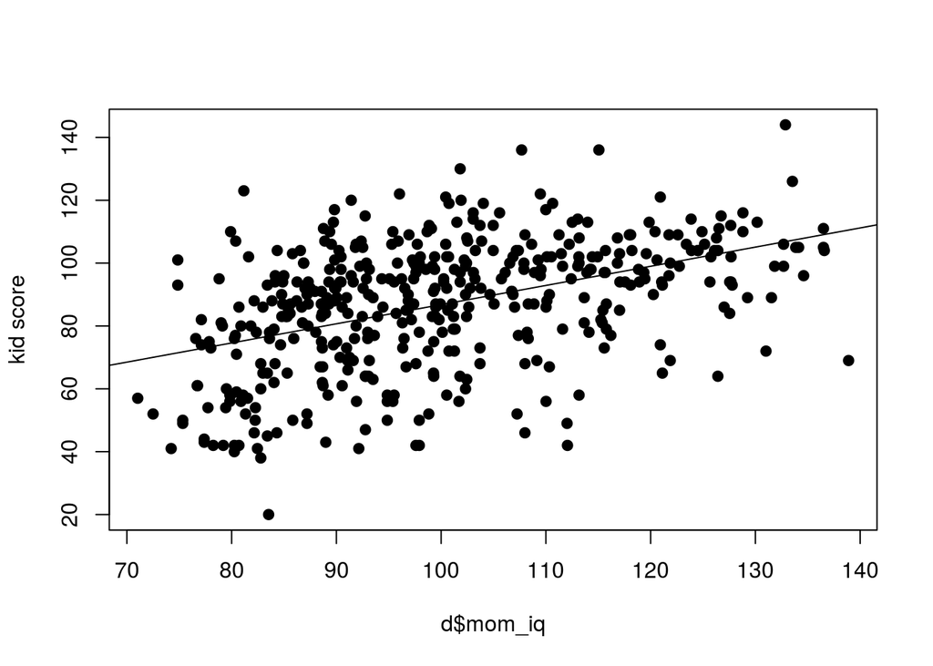

```r
plot(d$mom_iq, d$kid_score, pch = 19, ylab = "kid score")
abline(m2)
```

# 4 Logaritmos y porcentajes

$$\log(\hat y_i) = \hat \beta_0 + \hat \beta_1 \log(x_i)$$

Tomando diferenciales:

$$\frac{d \hat y_i}{\hat y_i} = \hat \beta_1 \frac{d x_i}{x_i} \Rightarrow \hat \beta_1 = \frac{\Delta \hat y_i / \hat y_i}{\Delta x_i / x_i}$$

Es decir, un incremento del 1% de x produce un incremento del $\beta_1$% de y.

```r
m3 = lm(log(kid_score) ~ log(mom_iq), data = d)
summary(m3)
```

```
##
## Call:
## lm(formula = log(kid_score) ~ log(mom_iq), data = d)
##
## Residuals:
##      Min       1Q   Median       3Q      Max
## -1.29684 -0.11879  0.05087  0.15956  0.54314
##
## Coefficients:
##             Estimate Std. Error t value Pr(>|t|)
## (Intercept)  0.67063    0.36088   1.858   0.0638 .
## log(mom_iq)  0.81847    0.07851  10.425   <2e-16 ***
## ---
## Signif. codes:  0 '***' 0.001 '**' 0.01 '*' 0.05 '.' 0.1 ' ' 1
##
## Residual standard error: 0.2413 on 432 degrees of freedom
## Multiple R-squared:  0.201,  Adjusted R-squared:  0.1992
## F-statistic: 108.7 on 1 and 432 DF,  p-value: < 2.2e-16
```

Luego un incremento del 1% del IQ de las madres produce un incremento del $0.81$% de la puntuación de los hijos.

# 5 Un regresor cualitativo y otro cuantitativo

## 5.1 Sin interacción

```r
m4 = lm(kid_score ~ mom_iq + mom_hs, data = d)
summary(m4)
```

```
##
## Call:
## lm(formula = kid_score ~ mom_iq + mom_hs, data = d)
##
## Residuals:
##     Min      1Q  Median      3Q     Max
## -52.873 -12.663   2.404  11.356  49.545
##
## Coefficients:
##             Estimate Std. Error t value Pr(>|t|)
## (Intercept) 25.73154    5.87521   4.380 1.49e-05 ***
## mom_iq       0.56391    0.06057   9.309  < 2e-16 ***
## mom_hsyes    5.95012    2.21181   2.690  0.00742 **
## ---
## Signif. codes:  0 '***' 0.001 '**' 0.01 '*' 0.05 '.' 0.1 ' ' 1
##
## Residual standard error: 18.14 on 431 degrees of freedom
## Multiple R-squared:  0.2141, Adjusted R-squared:  0.2105
## F-statistic: 58.72 on 2 and 431 DF,  p-value: < 2.2e-16
```

El modelo es:

$$kid\_score_i = \hat \beta_0 + \hat \beta_1 mom\_iq_i + \hat \beta_2 mom\_hsyes_i + e_i$$

- Si mom_hsyes = 0:

$$kid\_score_i = \hat \beta_0 + \hat \beta_1 mom\_iq_i + e_i$$

- Si mom_hsyes = 1:

$$kid\_score_i = (\hat \beta_0 + \hat \beta_2) + \hat \beta_1 mom\_iq_i + e_i$$

Por tanto:

- $\hat \beta_0$: puntuación de un chico cuya madre no ha terminado bachillerato y tiene un IQ=0
- $\hat \beta_1$: si comparamos chicos con el mismo valor de *mom_hsyes*, un incremento de un punto en *mom_iq* conlleva un aumento de $\widehat{kid\_score}$
- $\hat \beta_2$: para dos madres con el mismo IQ, una ternimó el bachillerato y la otra no, la puntuación de los chichos se diferencia en 5.95

Gráficamente:

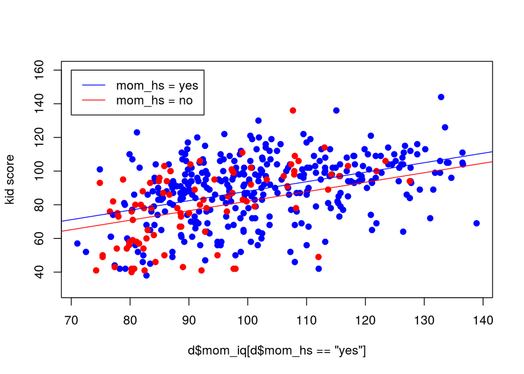

```r
plot(d$mom_iq[d$mom_hs=="yes"], d$kid_score[d$mom_hs=="yes"], col = "blue", pch = 19, ylab = "kid score", ylim = c(30,160))
points(d$mom_iq[d$mom_hs=="no"], d$kid_score[d$mom_hs=="no"], col = "red", pch = 19)
abline(a = m4$coeff[1], b = m4$coeff[2], col = "red")
abline(a = m4$coeff[1] + m4$coeff[3], b = m4$coeff[2], col = "blue")
legend(70,160, legend = c("mom_hs = yes","mom_hs = no"), col = c("blue","red"), lty = c(1,1))
```

## 5.2 Con interacción

```r
m5 = lm(kid_score ~ mom_iq * mom_hs, data = d)
summary(m5)
```

```
##
## Call:
## lm(formula = kid_score ~ mom_iq * mom_hs, data = d)
##
## Residuals:
##     Min      1Q  Median      3Q     Max
## -52.092 -11.332   2.066  11.663  43.880
##
## Coefficients:
##                  Estimate Std. Error t value Pr(>|t|)
## (Intercept)      -11.4820    13.7580  -0.835 0.404422
## mom_iq             0.9689     0.1483   6.531 1.84e-10 ***
## mom_hsyes         51.2682    15.3376   3.343 0.000902 ***
## mom_iq:mom_hsyes  -0.4843     0.1622  -2.985 0.002994 **
## ---
## Signif. codes:  0 '***' 0.001 '**' 0.01 '*' 0.05 '.' 0.1 ' ' 1
##
## Residual standard error: 17.97 on 430 degrees of freedom
## Multiple R-squared:  0.2301, Adjusted R-squared:  0.2247
## F-statistic: 42.84 on 3 and 430 DF,  p-value: < 2.2e-16
```

El modelo es:

$$kid\_score_i = \hat \beta_0 + \hat \beta_1 mom\_iq_i + \hat \beta_2 mom\_hsyes_i + \hat \beta_3 mom\_hsyes_i * mom\_iq_i + e_i$$

Que en realidad son dos modelos con distinta ordenada en el origen y distinta pendiente:

- Si mom_hsyes = 0:

$$kid\_score_i = \hat \beta_0 + \hat \beta_1 mom\_iq_i + e_i$$

- Si mom_hsyes = 1:

$$kid\_score_i = (\hat \beta_0 + \hat \beta_2) + (\hat \beta_1 + \hat \beta_3) mom\_iq_i + e_i$$

Por tanto:

- La puntuación del test para chicos cuya madre no completó el bachillerato y tienen IQ = 0 es -11.48 en promedio. Mirando el pvalor, $\beta_0 = 0$.
- La puntuación del test para los chicos cuya madre no completó el bachillerato aumenta 0.97 unidades cuando el IQ de la madre aumenta una unidad. Mirando el pvalor, $\beta_1 \neq 0$.
- La puntuación del test para chicos cuya madre completó el bachillerato y tienen IQ = 0 es (-11.48 + 51.27). Mirando el pvalor, $\beta_2 \neq 0$, la ordenada en el origen no es la misma para ambos grupos.
- La puntuación del test para los chicos cuya madre completó el bachillerato aumenta (0.97 - 0.48) unidades cuando el IQ de la madre aumenta una unidad. Mirando el pvalor, $\beta_3 \neq 0$, pendiente no es la misma para ambos grupos.

Gráficamente:

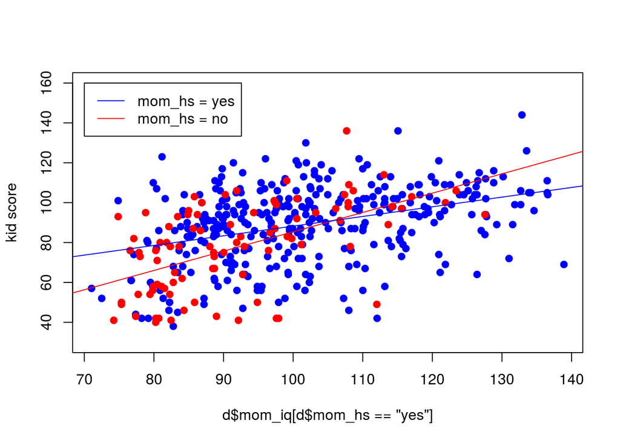

```r
plot(d$mom_iq[d$mom_hs=="yes"], d$kid_score[d$mom_hs=="yes"], col = "blue", pch = 19, ylab = "kid score", ylim = c(30,160))
points(d$mom_iq[d$mom_hs=="no"], d$kid_score[d$mom_hs=="no"], col = "red", pch = 19)
abline(a = m5$coeff[1], b = m5$coeff[2], col = "red")
abline(a = m5$coeff[1] + m5$coeff[3], b = m5$coeff[2] + m5$coeff[4], col = "blue")
legend(70,160, legend = c("mom_hs = yes","mom_hs = no"), col = c("blue","red"), lty = c(1,1))
```

# 6 Modelo con varios regresores

```r
m6 = lm(kid_score ~ mom_iq * mom_hs + mom_iq + mom_work, data = d)
summary(m6)
```

```
##
## Call:
## lm(formula = kid_score ~ mom_iq * mom_hs + mom_iq + mom_work,
##     data = d)
##
## Residuals:
##     Min      1Q  Median      3Q     Max
## -52.270 -11.964   2.106  11.230  45.219
##
## Coefficients:
##                  Estimate Std. Error t value Pr(>|t|)
## (Intercept)      -10.9473    13.7667  -0.795  0.42694
## mom_iq             0.9487     0.1492   6.357  5.3e-10 ***
## mom_hsyes         50.2287    15.5185   3.237  0.00130 **
## mom_work2          1.8354     2.8061   0.654  0.51343
## mom_work3          5.1585     3.2204   1.602  0.10993
## mom_work4          0.9189     2.4985   0.368  0.71321
## mom_iq:mom_hsyes  -0.4744     0.1636  -2.900  0.00393 **
## ---
## Signif. codes:  0 '***' 0.001 '**' 0.01 '*' 0.05 '.' 0.1 ' ' 1
##
## Residual standard error: 17.97 on 427 degrees of freedom
## Multiple R-squared:  0.2356, Adjusted R-squared:  0.2248
## F-statistic: 21.93 on 6 and 427 DF,  p-value: < 2.2e-16
```

$$score_i = \hat \beta_0 + \hat \beta_1 iq_i + \hat \beta_2 hsyes_i + \hat \beta_3 work2_i + \hat \beta_4 work3_i + \hat \beta_5 work4_i + \hat \beta_6 iq_i * hsyes_i + e_i$$